# A multilevel Bayesian model of pollination phenology in lodgepole pine

Susannah Tysor

April 15, 2019

```
##       DoY             Year          Site               Index
##  Min.   :122.0   Min.   :1997   Length:21854       Min.   :   1
##  1st Qu.:146.0   1st Qu.:2000   Class :character   1st Qu.:1199
##  Median :154.0   Median :2003   Mode  :character   Median :2610
##  Mean   :152.3   Mean   :2004                      Mean   :2584
##  3rd Qu.:159.0   3rd Qu.:2007                      3rd Qu.:3737
##  Max.   :174.0   Max.   :2011                      Max.   :5512
##
##   Phenophase            Sex               Orchard          Clone
##  Length:21854       Length:21854       Min.   :218.0   Min.   : 195
##  Class :character   Class :character   1st Qu.:220.0   1st Qu.:1466
##  Mode  :character   Mode  :character   Median :228.0   Median :1501
##                                        Mean   :230.7   Mean   :1486
##                                        3rd Qu.:228.0   3rd Qu.:1582
##                                        Max.   :339.0   Max.   :4425
##                                                        NA's   :24
##      Date           Phenophase_Derived     TreeID        mean_temp
##  Length:21854       Min.   :1.000      Min.   :  1.0   Min.   : 6.29
##  Class :character   1st Qu.:2.000      1st Qu.:193.0   1st Qu.:11.07
##  Mode  :character   Median :2.000      Median :399.0   Median :12.70
##                     Mean   :1.993      Mean   :396.2   Mean   :12.96
##                     3rd Qu.:2.000      3rd Qu.:579.0   3rd Qu.:14.45
##                     Max.   :3.000      Max.   :897.0   Max.   :22.50
##
##  daily_forcing_type daily_forcing    forcing_accum     SPU_Name
##  Length:21854       Min.   : 2.732   Min.   :189.7   Length:21854
##  Class :character   1st Qu.: 5.822   1st Qu.:298.5   Class :character
##  Mode  :character   Median : 7.333   Median :322.7   Mode  :character
##                     Mean   : 7.852   Mean   :327.0
##                     3rd Qu.: 9.232   3rd Qu.:351.3
##                     Max.   :19.343   Max.   :476.8
##
```

## Conceptual Analysis

Pollination phenology in lodgepole pine refers to the timing of two events - pollen shed and cone receptivity. I want to estimate the beginning, end, and length of both events.

### Phenology data summary

Pollen shed almost always begins prior to or simultaneously with cone receptivity. Pollen shed finishes before the receptive period is over less than half the time and sometimes finishes after the receptivity period is done.

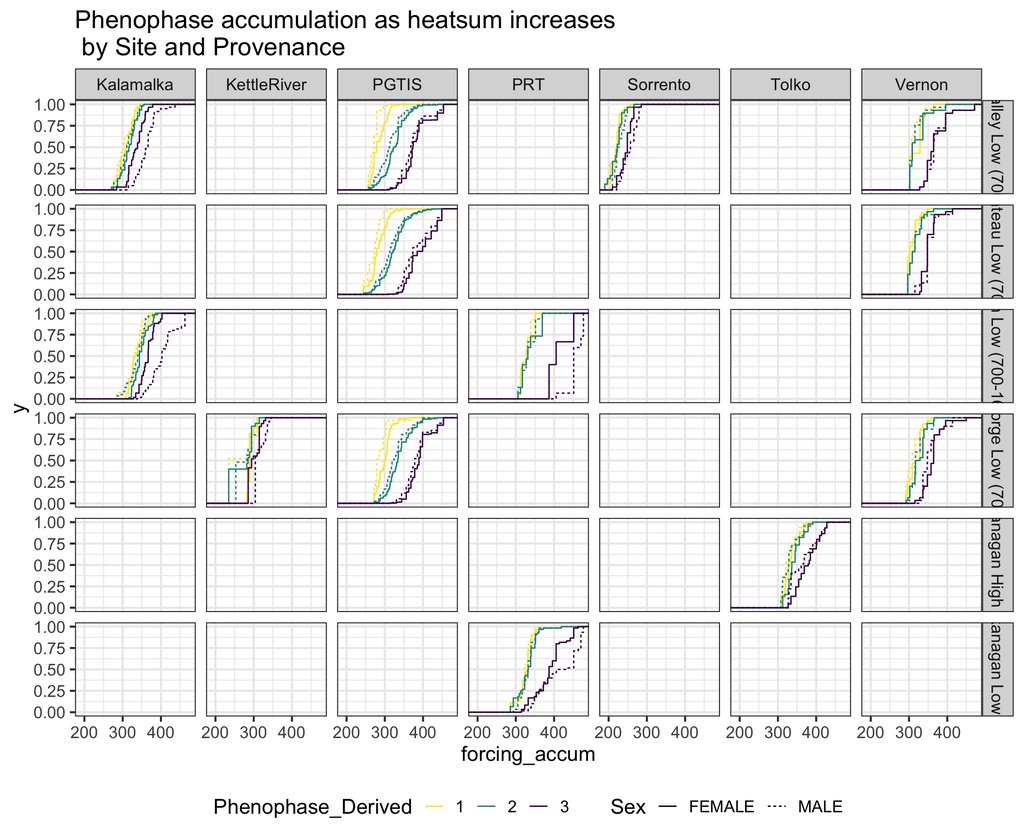

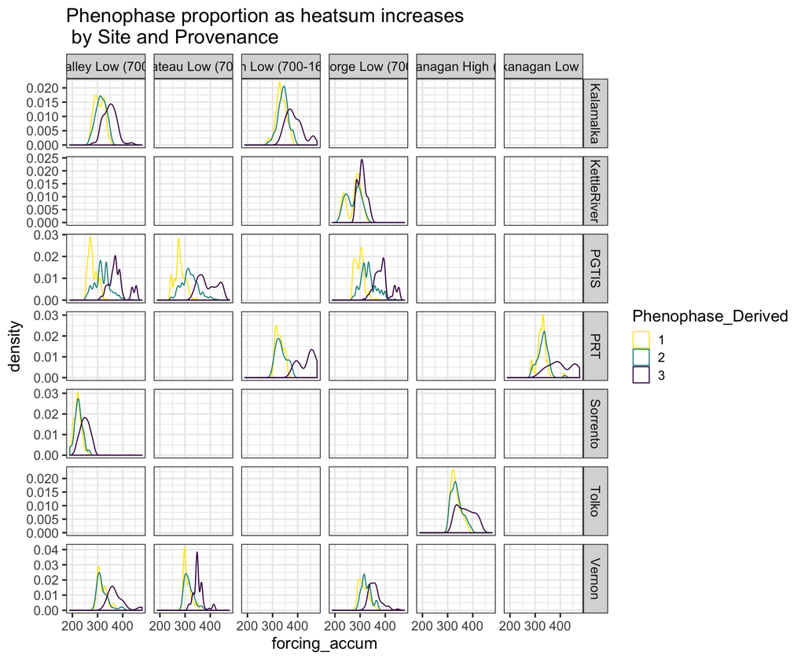

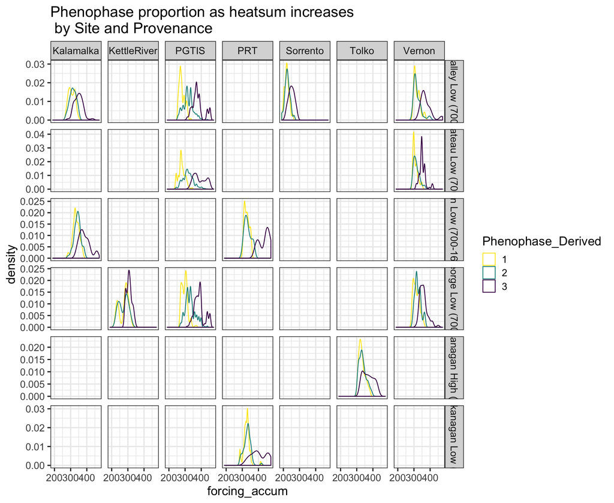

As the developmental process for pollen shed and cone receptivity appears to be logistic (Sarvas 1972), I will use a logistic model. A logistic model has two parameters. $k$ affects the speed of transition and $h$ determines the time (“location”) of transition. $k$ must be positive and between 0 and 1. $k$ near 0 is a slow transition. $k$ near one is a near instantaneous transition. $h$ is the inflection point of the curve, in our case, the point at which a given tree is 50% likely to have transitioned from state $s$ to state $s+1$

$$y = \frac{1}{1+e^{-k(x-h)}}$$

There are two transitions I need to model for each event - 1) transitioning from not started to active and 2) from active to completed.

Since there are two transitions, I will use an ordered logistic model that describes the likelihood of being in each phenological state $s$ given a linear model $\eta$ and cutpoints $c$.

For $S=3$ categories

$$\small{\text{OrderedLogistic}(s|~\eta,c) = \left\{ \begin{array}{ll} 1 -
\text{logistic}(\eta - c_1) & \text{if } s = 1, \\[4pt]
\text{logistic}(\eta - c_1) - \text{logistic}(\eta - c_2) &
\text{if } s=2, \text{and} \\[4pt] \text{logistic}(\eta -
c_3) - 0 & \text{if } s = 3. \end{array} \right.}$$
Where $\eta$ is a linear model with explanatory variable x - in our case, forcing units (*e.g.* heatsum), and $k$ slope
$$\eta = k x \\$$
This model is parameterized slightly differently than the logistic model above. In this model

$$k=k \\
h_s=\frac{c_s}{k}\\$$

An ordered logistic model respects the ordering of the phenological states and generates two curves - one representing the “not-yet to active” transition and the other the “active to complete” transition. The transition from before not-yet to not-yet is not meaningful and $c_1$ is set to 0.

Adding intercept components to $\eta$ shifts the location and they are added to the cutpoints when calculating $h_s$. For example, adding a provenance effect to eta

$$\eta=kx + \alpha_{provenance}$$
means that the location $h_s$ is calculated as

$$h_s = \frac{c_s+\alpha_{provenance}}{k}$$

In this example parameterization, cutpoints are not sex or population specific. $\alpha$ components in $\eta$ affect both transitions equally. So a provenance effect $\alpha_{provenance}$ will shift both the transition from state from 1 to 2 and from 2 to 3 by the same amount. Is this (biologically) correct?

Sarvas’s experimental work on development in trees says that

> the regression of the rate of progress of the active period on temperature is the same for all the genera, species, individual trees and the different parts of the active period investigated in this study. [@Sarvas1972]

His study included *Populus*, *Betula*, *Alnus* as well as *Picea abies*, *Pinus sylvestris*, and 2 *Larix* species.

The unit for the “rate of progress” is period units/hour where period units are 1/5 of the cycle interval that the active period of a given genotype progresses in 1 hour at a constant temperature of 10 degrees C.

This does not mean that everything should have the same slope ($k$). It does mean that I can use the same forcing units for everything.

I will parameterize this model with effects on k (slopes) from Sex and Provenance and effects on location (intercepts) from Sex, Site, Provenance, Clone, and Year.

### Important model assumptions

In a model where effects are included in eta, any effect influences both curves identically. That is, curves can be shifted to the left or right by an effect, but cannot be shifted in opposite directions.

I am making assumptions about the kinds of effects that are possible in what I choose to include on both slopes and intercepts.

#### Alternative parameterizations

##### Effects on each cutpoint

I could parameterize the model differently I think. For example, considering just the effects of sex and provenance:

$$\eta = (k + k_{sex} + k_{provenance})x \\
c_1 = \alpha + \alpha_{sex} + \alpha_{provenance} \\
c_2 = \beta + \beta_{sex} + \beta_{provenance}$$
This means making way more priors, but I think makes biological sense!
In old versions of my model, whatever effects there are from provenance, clone, ramet, etc shift all $h_s$ by the same amount.

This model would have at least double the number of parameters as the other parameterization and may be very difficult or impossible to fit. I did successfully create a model with different effects on both cutpoints, but wasn’t able to make the model fit more than one group. This is a technical issue and not a theoretical one.

##### Difference between cutpoints

Instead of modeling intercepts as part of $\eta$ or on each cutpoint individually, I could model the *difference* between cutpoints. This is my preferred approach, but I cannot make any versions of this with actual effects included work. I’ve asked for help [here](https://discourse.mc-stan.org/t/add-effects-to-difference-between-cutpoints-in-multilevel-ordered-logistic-model/8421).

I think this makes sense biologically. I’d estimate some main cutpoints and then the effects on the difference would determine the precise location. A positive male effect on the difference would mean that the curves are pushed apart. A negative male effect would mean the curves are pulled closer together. This is still symmetric, but could capture an effect like - males begin flowering at lower forcing units and stop flowering at higher forcing units than females.

### How to include effects of sex, provenance, etc.

The first question is whether to include the effect in the speed of transition $k$ or the locations.

### Male and female in same model?

I am not sure whether to include male and female strobili in the same model. Male and female strobili develop separately but as as part of the same elongating stem.

If I include them in the same model, unless I do some really crazy parameterization, then I am assuming that clonal, provenance, tree, and site effects are the same across sexes. For example, a clone that has a lower threshold has a lower threshold for both males and females.

I could do a test for this by running separate models or adding *a lot* of parameters.

The location must vary by sex. If there isn’t a cutpoint component for sex, then curves will be identical for males and females unless the $k$ is allowed to vary. Since $h_s$ depends on $k$ as well as the cutpoints, changes in $k$ can shift the location of the curve.

Previous model runs have been letting $k$ vary by sex, but not the location. I believe that was a mistake. They could very easily have different $k$ and $h_s$

### Should the sex component have partial pooling?

No! Sex components should not be pooled across males and females. They’re connected but separate and I believe they should be allowed to vary completely independently.

### What about pooling for other effects?

For clone, site, year, and provenance, I believe partial pooling is the right decision. No pooling will overfit and exaggerate effects, but ignoring the effects (total pooling) will ignore effects I’m testing for (provenance) or that undoubtedly exist (clone, site).

## So what does the model look like?

$f$ accumulated forcing units

## What about calculating the start, end, and length of the phenological period?

## Woah now let’s calm down and do a simpler version. Maybe look back at an old workflow and try again.

## Fit a model to simulated data

Simulate data from an ordered logistic distribution with three states and forcing values from real data.

7 sites, 6 provenances, and 10 observations for each of 15 individuals at different forcing temperatures

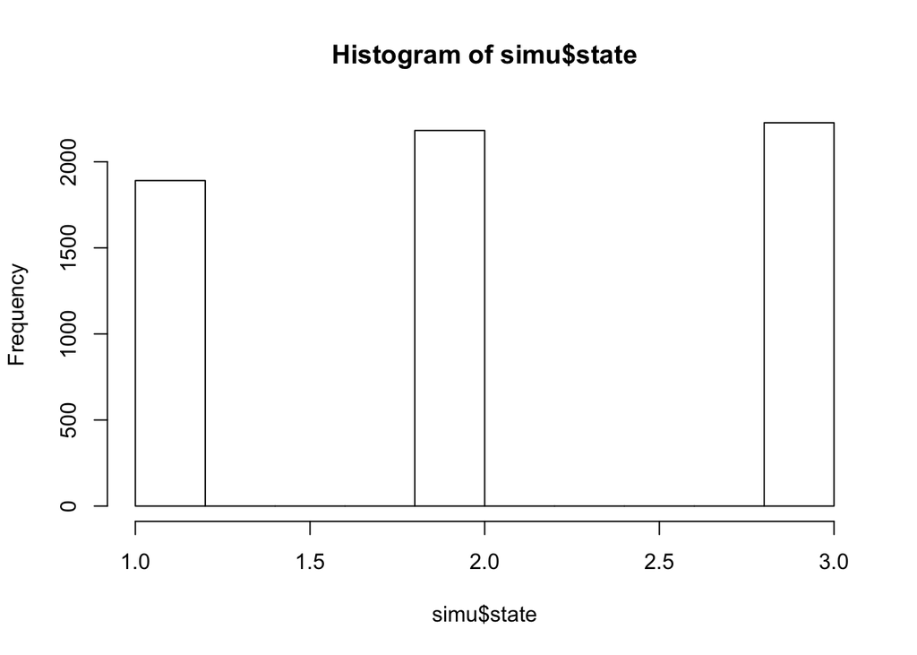

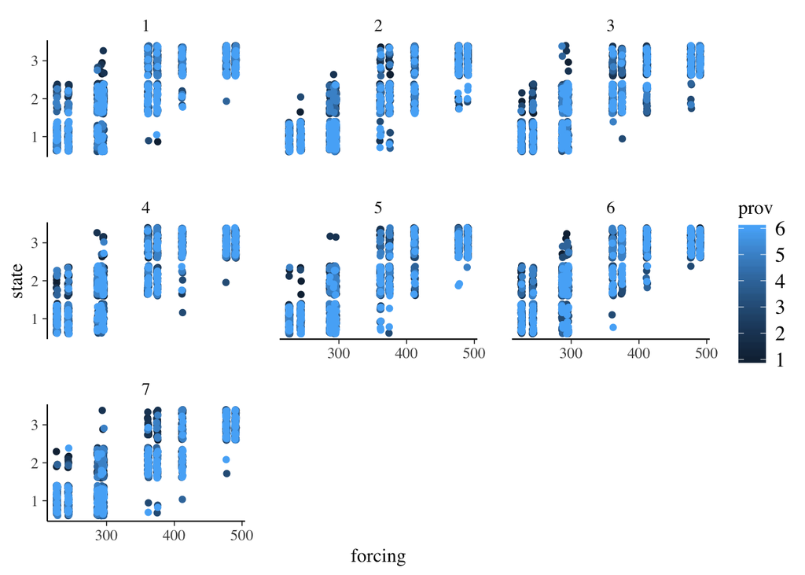

## Fit model to simulated data

### Consider fit of model to simulated data

If cutpoints prior is a single gamma distribution, cutpoints are not returned well. Neither is beta. Edited model so prior is on the difference between cutpoints rather than the cutpoints as a group.

Also want to try - modeling cutpoints with separate linear models -

## Real data

### Model version with correlation

#### Simplest - sex only

```
##   DoY Year Index Orchard Phenophase_Derived mean_temp daily_forcing
## 1 125 2006     1     230                  1  11.53851      6.229946
## 2 125 2006     1     230                  1  11.53851      6.229946
## 3 126 2006     1     230                  2  13.56202      8.238096
## 4 128 2006     1     230                  3  11.53460      6.226425
## 5 124 2006     2     230                  1   9.70692      4.738140
## 6 124 2006     2     230                  1   9.70692      4.738140
##   forcing_accum CloneID OrchardID ProvenanceID SiteID SexID YearID
## 1      309.3954      90         7            1      1     1     10
## 2      309.3954      90         7            1      1     1     10
## 3      317.6335      90         7            1      1     1     10
## 4      331.3024      90         7            1      1     1     10
## 5      303.1654      97         7            1      1     1     10
## 6      303.1654      97         7            1      1     1     10
```